# In Class Work February 5th

# Graph 8

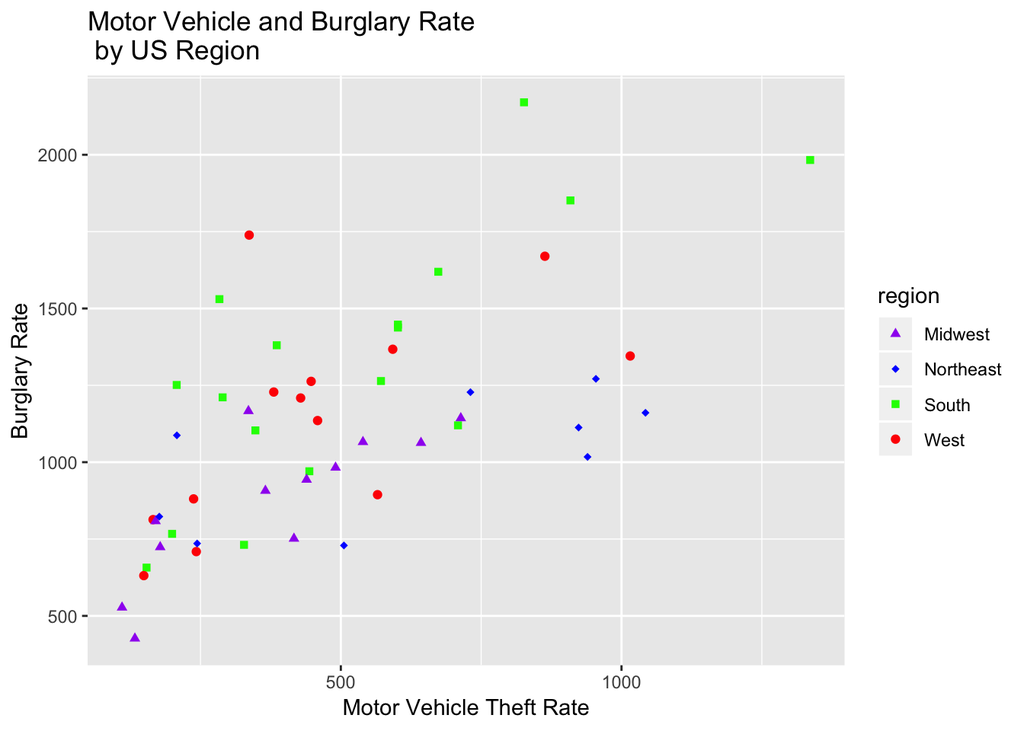

```r
crime_1990 <- filter(crime,Year==1990, State!="United States-Total")

northeast_states<- c("Connecticut", "Maine", "Massachusetts", "New Hampshire", "Rhode Island", "Vermont", "New Jersey", "New York", "Pennsylvania")
midwest_states <- c("Illinois", "Indiana", "Michigan", "Ohio", "Wisconsin", "Iowa", "Kansas", "Minnesota", "Missouri", "Nebraska", "North Dakota", "South Dakota")
south_states <- c("Delaware", "Florida", "Georgia", "Maryland", "North Carolina", "South Carolina", "Virginia", "District of Columbia", "West Virginia", "Alabama", "Kentucky", "Mississippi", "Tennessee", "Arkansas", "Louisiana", "Oklahoma", "Texas")
west_states <- c("Arizona", "Colorado", "Idaho", "Montana", "Nevada", "New Mexico", "Utah", "Wyoming", "Alaska", "California", "Hawaii", "Oregon", "Washington")

crime_1990 <- mutate(crime_1990, region=ifelse(State %in% northeast_states, "Northeast",
                                                 ifelse(State %in% midwest_states, "Midwest",
                                                        ifelse(State %in% south_states, "South",
                                                               ifelse(State %in% west_states, "West","NA")))))

ggplot(crime_1990)+
  geom_point(aes(x=`Motor vehicle theft rate`,
                 y=`Burglary rate`,
                 color=region,
                 shape=region))+
  scale_shape_manual(values=c("Midwest"=17,"Northeast"=18,"South"=15,"West"=19))+
  scale_color_manual(values=c("West"="red", "Northeast"="blue", "South"="green", "Midwest"="purple"))+
  labs(x="Motor Vehicle Theft Rate",y="Burglary Rate",title="Motor Vehicle and Burglary Rate\n by US Region")
```

Graph 8: A scatter plot showing (for each state) the motor vehicle theft rate in 1990 along the horizontal axis and the burglary rate in 1990 along the vertical axis. A different color and shape is used for the points representing states from each of the 4 regions. A solid green square is used for the South, a solid red circle for the West, a solid purple triangle for the Midwest, and a solid blue diamond for the Northest.

# Graph 9

```r
crime <- read_csv("CrimeStatebyState.csv")
```

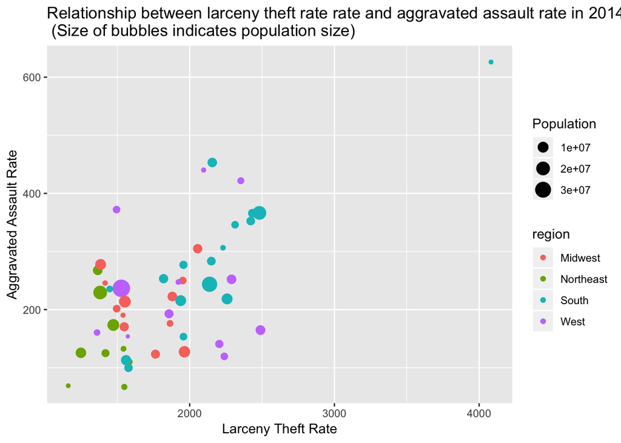

```r
crime_2014 <- filter(crime,Year==2014,State!="United States-Total")

northeast_states<- c("Connecticut", "Maine", "Massachusetts", "New Hampshire", "Rhode Island", "Vermont", "New Jersey", "New York", "Pennsylvania")
midwest_states <- c("Illinois", "Indiana", "Michigan", "Ohio", "Wisconsin", "Iowa", "Kansas", "Minnesota", "Missouri", "Nebraska", "North Dakota", "South Dakota")
south_states <- c("Delaware", "Florida", "Georgia", "Maryland", "North Carolina", "South Carolina", "Virginia", "District of Columbia", "West Virginia", "Alabama", "Kentucky", "Mississippi", "Tennessee", "Arkansas", "Louisiana", "Oklahoma", "Texas")
west_states <- c("Arizona", "Colorado", "Idaho", "Montana", "Nevada", "New Mexico", "Utah", "Wyoming", "Alaska", "California", "Hawaii", "Oregon", "Washington")

crime_2014 <- mutate(crime_2014, region=ifelse(State %in% northeast_states, "Northeast",
                                                 ifelse(State %in% midwest_states, "Midwest",
                                                        ifelse(State %in% south_states, "South",
                                                               ifelse(State %in% west_states, "West","NA")))))

ggplot(crime_2014)+
  geom_point(aes(x=`Larceny-theft rate`,y=`Aggravated assault rate`,size=`Population`,color=region))+
  labs(x="Larceny Theft Rate",y="Aggravated Assault Rate",title="Relationship between larceny theft rate rate and aggravated assault rate in 2014\n (Size of bubbles indicates population size)")
```

Graph 9: A scatter plot showing (for each state) the larceny theft rate rate in 2014 along the horizontal axis and the aggravated assault rate in 2014 in along the vertical axis. The size of each point is mapped to that state’s population.